# RNAsep2 De analysis report

Thomas Sol Dourdin

2025-04-09

# **Differential gene expression analysis using DESeq2**

The differential gene expression analysis was performed using the DESeq2 R package.

The three treated conditions: **Hg**, **CO2** and **Hg+CO2** were independently analysed against the control condition: **CT**, using the *Wald test* implemented in DESeq2 (pairwise comparison).

The threshold used were : **pvalue < 0.05** & **|log2FoldChange| > 0.5**.

Regarding the **Hg** & **CO2** conditions, only few genes were differentially expressed : **5** (fig.1) and **15** (fig.2), respectively. However, **315 DEGs** were found in the **Hg+CO2** condition, suggesting a synergistic interaction between both stressors when they occur concomitantly.

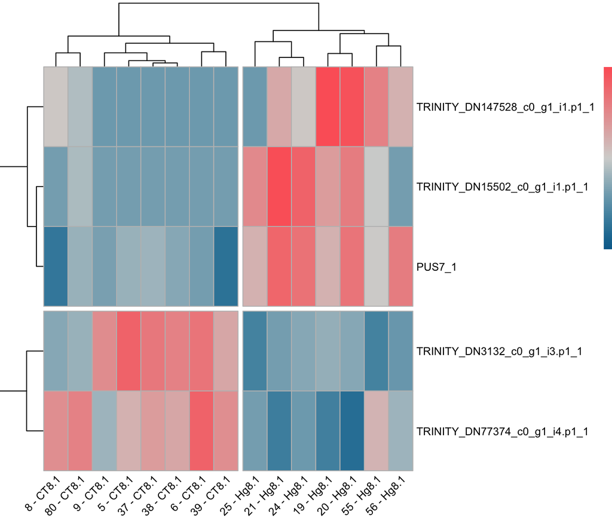

Figure 1: Heatmap representing the relative gene expression level of the 5 DEGs between MeHg and CT conditions.

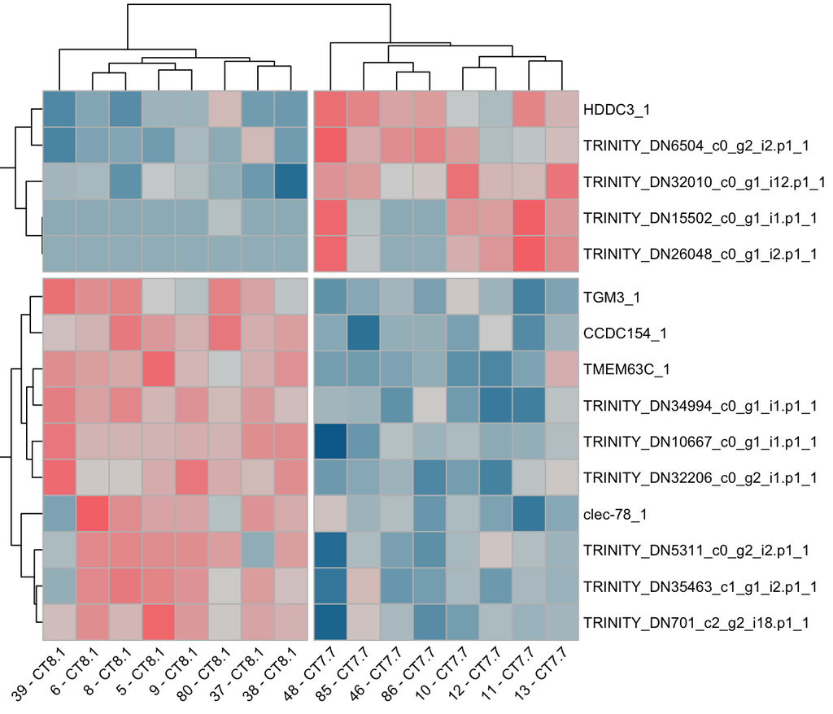

Figure 2: Heatmap representing the relative gene expression level of the 15 DEGs between *p*CO~2and CT conditions.

As shown in the Figure 3 below, only one DEG was found to be common to all conditions but a substantial proportion of DEGs from **Hg** and **CO2** conditions were also affected by the **Hg+CO2** treatment (60% and 27%, respectively).

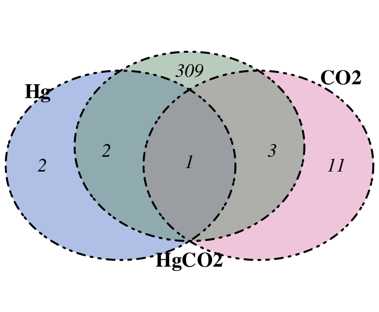

Only one DEG between Hg and CT conditions was annotated: *PUS7* (BP: rna metabolic process), who’s found to be implicated in “intellectual” developmental disorder with abnormal behaviour (in human).

In *p*CO~2 vs CT, 5 among the 15 DEGs are annotated: TGM3 (BP: protein metabolic process, development process and cell differentiation), CCDC154 (à regarder), TMEM63C (pas décrit chez les mollusques), clec-78 and HDDC3…

–> There is nothing evident from these to comparisons.

Among the 315 DEGs from the **Hg+CO2** condition, **61 were up-regulated** and **254 were down-regulated** (cf. heatmap).

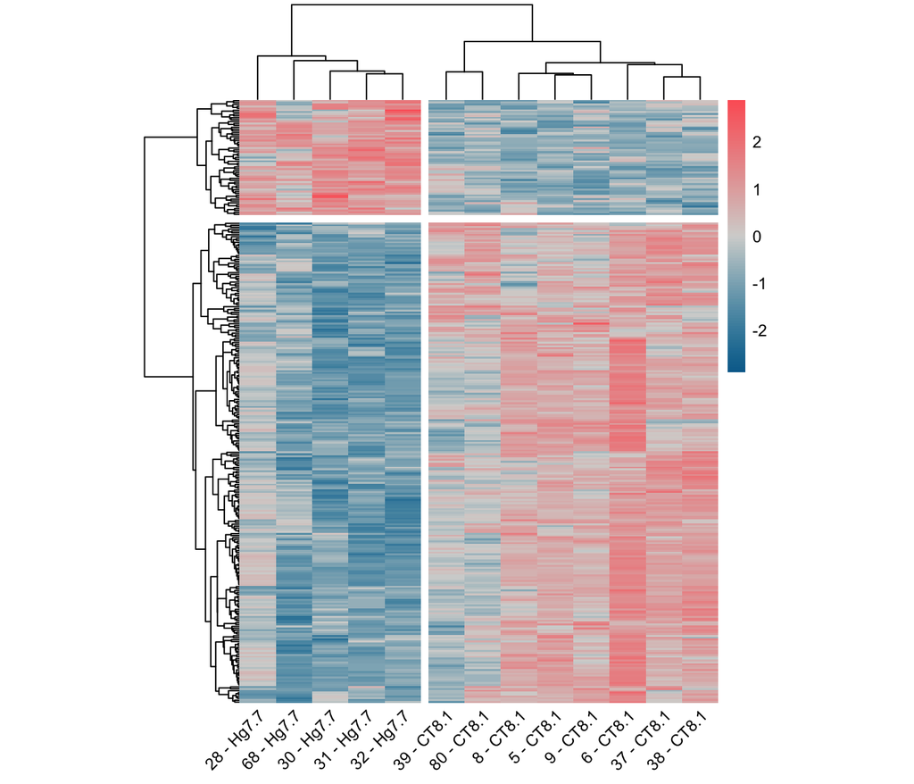

Figure 4: Heatmap representing the relative gene expression level of the 315 DEGs between *p*CO~2+MeHg and CT conditions.

**The functional enrichment analysis** was performed on the whole gene expression dataset used for the differential analysis with the GOMWU utility using a MWU-based method (see https://github.com/z0on/GO_MWU).

Overall, 158 biological processes were found to be significantly enriched in the **Hg+CO2** condition. The more significants are represented in Figure 5.

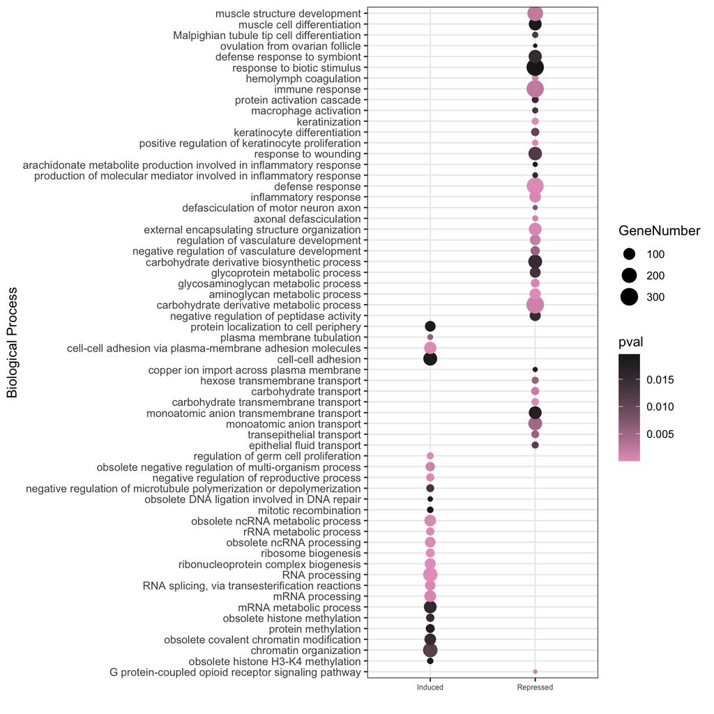

Figure 5: Main biological processes found to be enriched in *p*CO~2+MeHg condition following the MWU-based method.

Noteworthy, among the main repressed GOterms are biological processes related to the defense of the organism against external stress (i.e. $*immune response*, *defense response*, *response to wounding*, *inflammatory response*, *protein activation cascade* etc.). This suggests a decrease of their ability to cope with external stress. A possible link to the alteration of anti-predatory behaviour may be discussed. Moreover, genes implicated in the development of musclar tissues (i.e. *muscle development* and *muscle cell differentiation*), along with the development of neuronal network (i.e. *defasciculation of motor neuron axon*, *axonal defasciculation*) are also repressed, corroborating behavioral evidences for the neurotixicity of the two stressors.

On the other side, there is a clear induction of RNA processing-related genes (*ribosome biogenesis*, *RNA splicing*, *mRNA processing*) as well as putative epigenetic regulation (*chromatin organization*, *obsolete histone H3-K4 methylation*, *obsolete covalent chromatin modification*) which may be characteristic of a response to environmental stress. Based on this, investigating epigenetic modifications would be quite relevant. (**See also the growing literature on the topic**).

To go further, a weighted gene co-expression network (WGCNA) analysis was performed. Its aim is to identify clusters of genes (*modules*) defined by a significant correlation of their expression. Then the correlation between the so-called *modules* and some behavioural/environmental traits is tested to define *modules of interest* (those exhibiting a significant correlation with a given trait). In these modules, we can (i) conduct a GO enrichment analysis and (ii) identify *hub genes* (i.e. the 1% or 5% most highly connected genes among the module, expected to be the more representative).

Here, the analysis resulted in **34 modules that were tested against behavioural parameters** investigated by Antoine during his PhD (Figure 6). **Three modules of interest were found to be correlated with the uniform score**: Maroon, Steelblue and plum3. They encompass 994, 247 and 47 genes, respectively. A simplified representation of the modules has been displayed on Cytoscape applying edge threshold from 0.1 to 0.21 depending on network density (Figure 7).

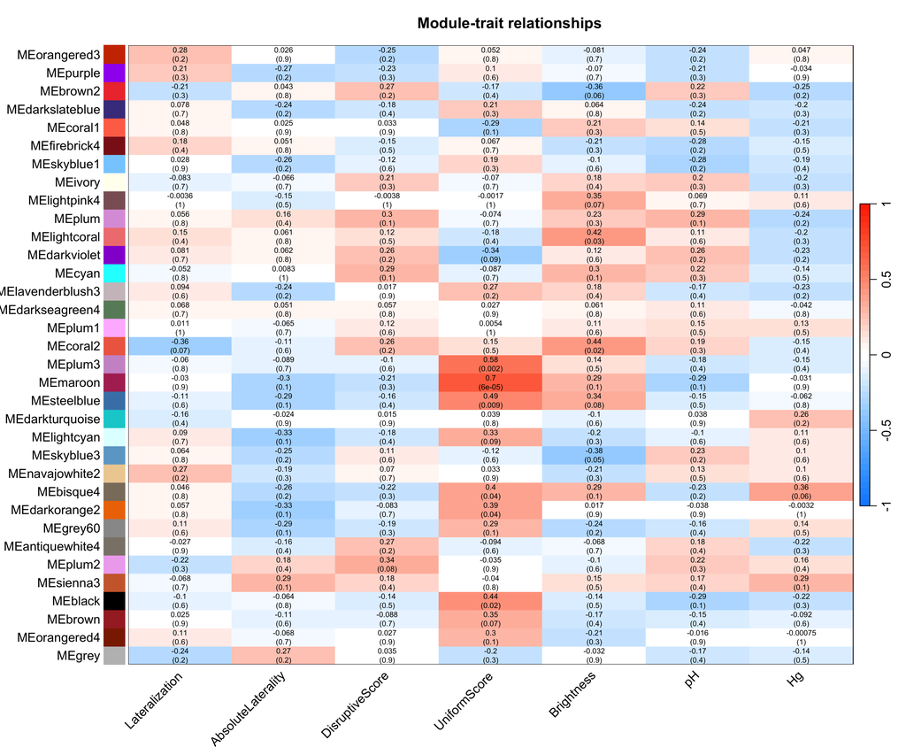

Figure 6: Module-Trait correlation matrix.

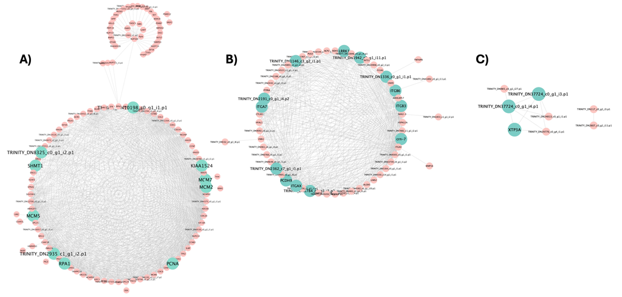

Figure 7: Modules positively correlated to the uniform score. Gene in green are hub genes. A) Maroon, B) Steelblue, C) Plum3.

In the Maroon module, 265 GO terms were found to be enriched, among which the more representative were mostly related to cell cycle/meiosis/mitosis (e.g. *DNA replication initiation*, *regulation of cell cycle checkpoint*, *chromosome movement towards spindle pole*, *centromere complex assembly*) along with some metabolic processes (e.g. *deoxyribonucleotide*, *tatrahydrofolate*) or the *epigenetic negative regulation of gene expression* (Figure 8).

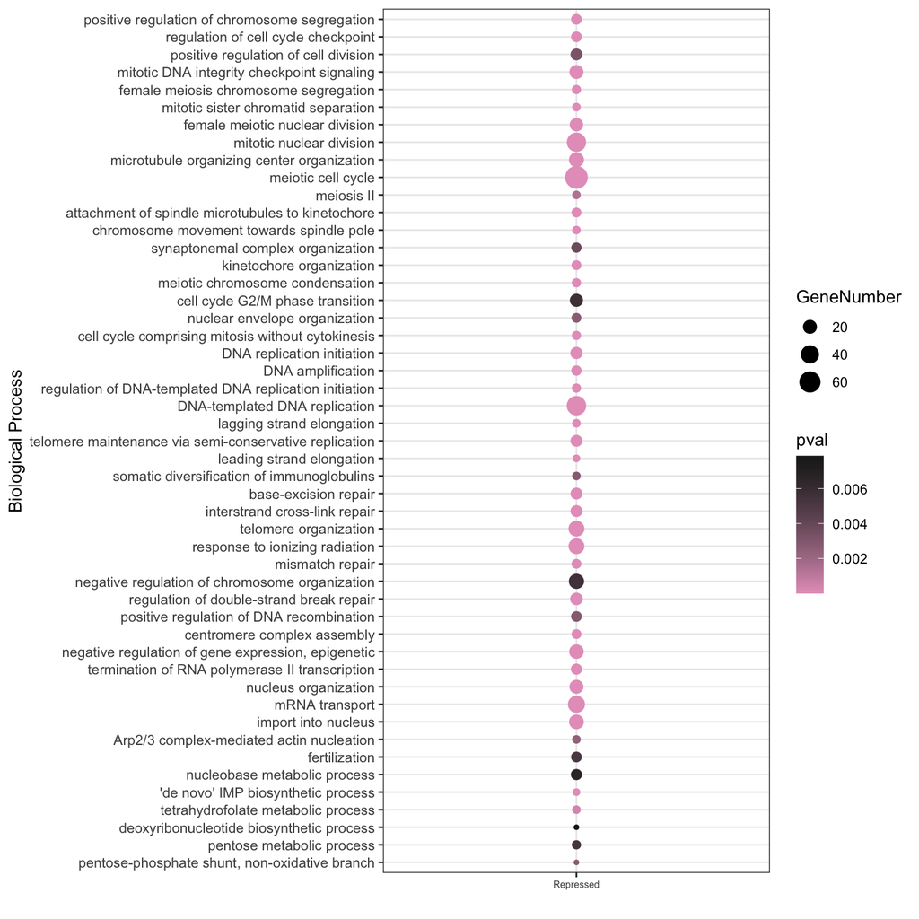

Figure 8: Main biological processes found to be enriched in the Maroon module.

The Steelblue module was associated with 157 enriched GOterms. The more representative corresponds to repair of tissue injuries (e.g. *defense response*, *wound healing*, *positive regulation of epithelial cell proliferation*, *lymphocyte migration*) (Figure 9).

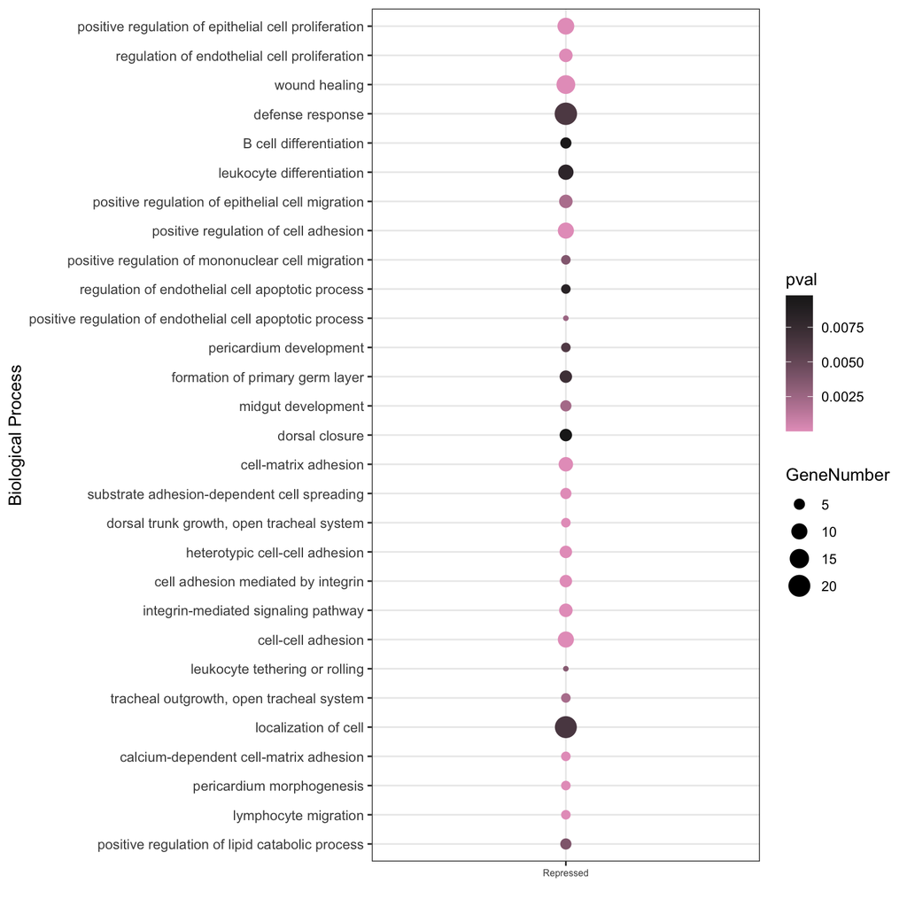

Figure 9: Main biological processes found to be enriched in the Steelblue module.